# Reproducible Research (PA1)

David Rodriguez

## Loading and preprocessing the data

Read the data having copied the source file in the working directory

```r
rawdata<-read.csv("activity.csv",colClasses=c("numeric","character","numeric"))
missingvalues<-is.na(rawdata$steps)
```

There are three variables in the dataset:

- steps: Number of steps taking in a 5-minute interval (missing values are coded as NA)
- date: The date on which the measurement was taken in YYYY-MM-DD format
- interval: Identifier for the 5-minute interval in which measurement was taken

```
##   steps       date interval
## 1    NA 2012-10-01        0
## 2    NA 2012-10-01        5
## 3    NA 2012-10-01       10
## 4    NA 2012-10-01       15
## 5    NA 2012-10-01       20
## 6    NA 2012-10-01       25
```

The total number of rows for this file is 17568.

Before moving on, it is important to prepare the system loading the packages and setting the proper environment variables

```r
library(dplyr)
library(lattice)
Sys.setlocale("LC_TIME", "English")
```

First transformation: the date from string to POSIX

```r
rawdate<-strptime(rawdata$date,format("%Y-%m-%d"))
```

Second transformation: create a new variable, the day of the week, and a factor based on these values (Weekday: Mon-Fri/ Weekend: Sat,Sun)

```r
  rawweekday<-weekdays(rawdate)
  typeofday<-factor(rawweekday,ordered=TRUE)
levels(typeofday)<-c("Weekday","Weekday","Weekend","Weekend","Weekday","Weekday","Weekday")
```

Merge the two new columns in the dataset

```r
finalrawdata<-cbind(rawdata,rawdate,typeofday)
```

Third transformation: obtain a secondary dataset discarding the missing values, to be used in the first part of the analysis

```r
rawdatawoNA<-finalrawdata[!missingvalues,]
```

The total number of rows for this clean dataset is 15264.

## What is mean total number of steps taken per day?

The objective of this section is to analyze the total number of steps per day.

Firstly, create the summarized dataset: sum, mean and median of steps per day from the dataset without missing values

```r
sumstepsbydate<-summarise(group_by(rawdatawoNA,rawdate),totalsteps=sum(steps),meansteps=mean(steps),mediansteps=median(steps))
```

Draw an histogram based on the total number of steps per date. The number of bars can vary depending on the volume of the data.

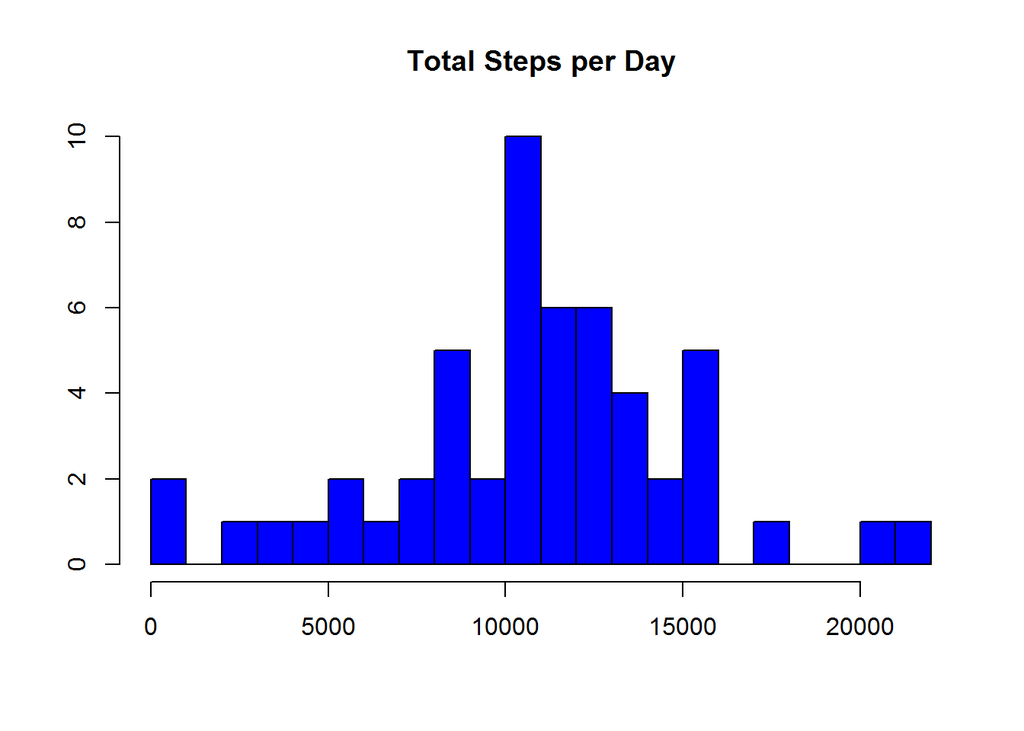

```r
hist(sumstepsbydate$totalsteps,20,main="Total Steps per Day",xlab="",ylab="",col="blue")
```

Report the mean and the median per date

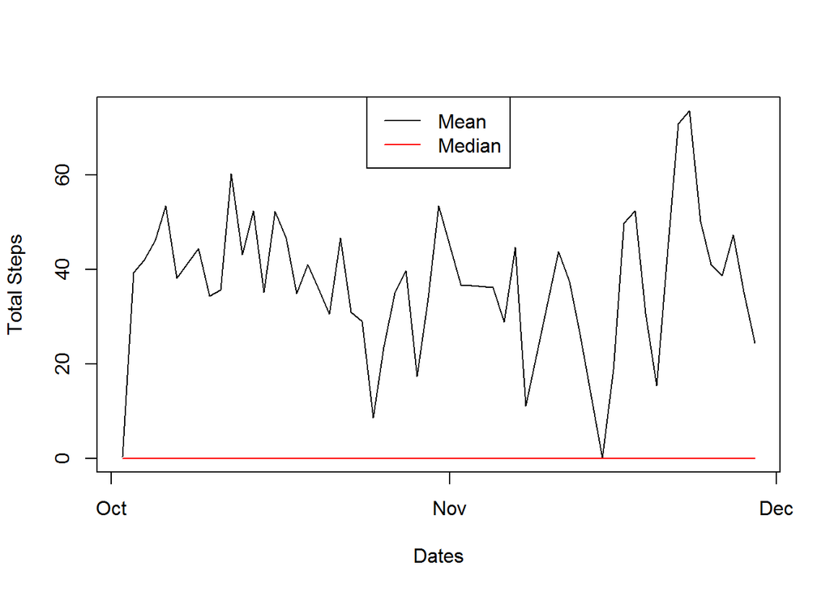

```r
  plot(sumstepsbydate$rawdate,sumstepsbydate$meansteps,type="l",col="black",ylab="Total Steps",xlab="Dates")
  lines(sumstepsbydate$rawdate,sumstepsbydate$mediansteps,type="l",col="red")
legend("top",legend=c("Mean","Median"),col=c("black","red"),lty=c(1,1))
```

## What is the average daily activity pattern?

Calculate the total number of steps per interval from the dataset without missing values

```r
sumstepsbyinterval<-summarise(group_by(rawdatawoNA,interval),totalsteps=sum(steps),meansteps=mean(steps))
```

Plot the total steps per interval

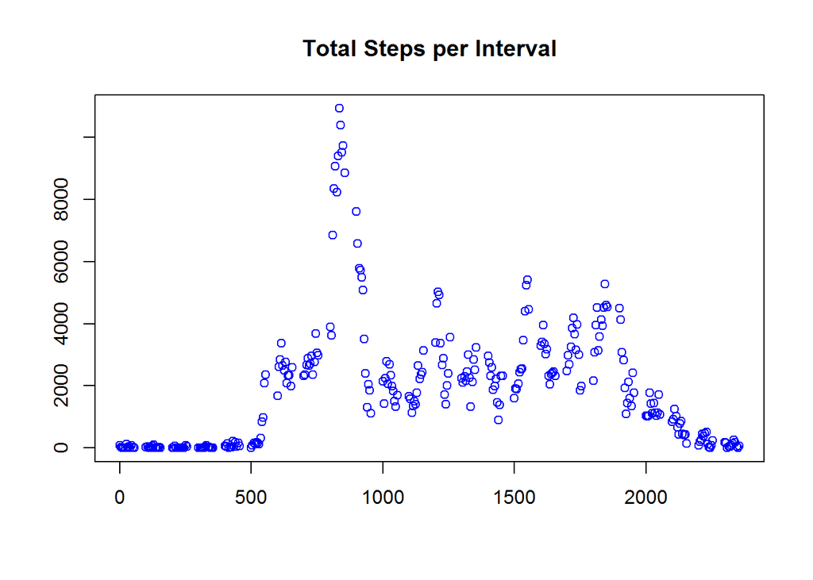

```r
plot(sumstepsbyinterval$interval,sumstepsbyinterval$totalsteps,type="p",main="Total Steps per Interval",xlab="",ylab="",col="blue")
```

The interval with the maximum total number of steps in average is 835.

```r
sumstepsbyinterval[which.max(sumstepsbyinterval$totalsteps),]
```

```
## Source: local data frame [1 x 3]
##
##   interval totalsteps meansteps
## 1      835      10927  206.1698
```

## Imputing missing values

Quick analysis of the missing values

```r
summary(missingvalues)
```

```
##    Mode   FALSE    TRUE    NA's
## logical   15264    2304       0
```

The missing values will be replaced by the average of each interval.

```r
##Duplicate the steps
modifiedsteps<-finalrawdata$steps
for (i in 1:length(modifiedsteps)){
  ##Replace NAs by the mean of the interval
  if (is.na(modifiedsteps[i]))    {
    modifiedsteps[i]=sumstepsbyinterval$meansteps[sumstepsbyinterval$interval==finalrawdata$interval[i]]
  }
}
finaldata<-cbind(finalrawdata,modifiedsteps)
```

The dataset *finaldata* contains the original data plus the additional columns (*rawdate*, *typeofday* and *modifiedsteps*).

Summarise by date to create the same graphs as the previous point but based on the complete and modified dataset

```r
sumnewstepsbydate<-summarise(group_by(finaldata,rawdate),totalsteps=sum(modifiedsteps),meansteps=mean(modifiedsteps),mediansteps=median(modifiedsteps))
```

Draw an histogram based on the total number of steps per date

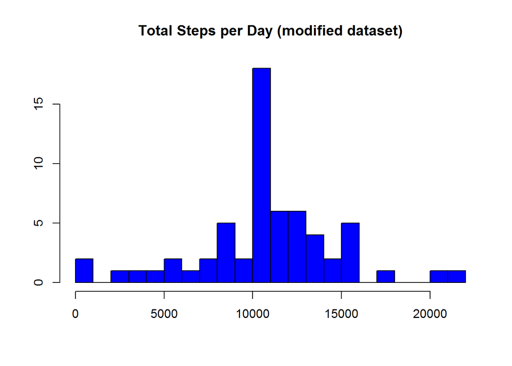

```r
hist(sumnewstepsbydate$totalsteps,20,main="Total Steps per Day (modified dataset)",xlab="",ylab="",col="blue")
```

Report the mean and the median per date for the new dataset

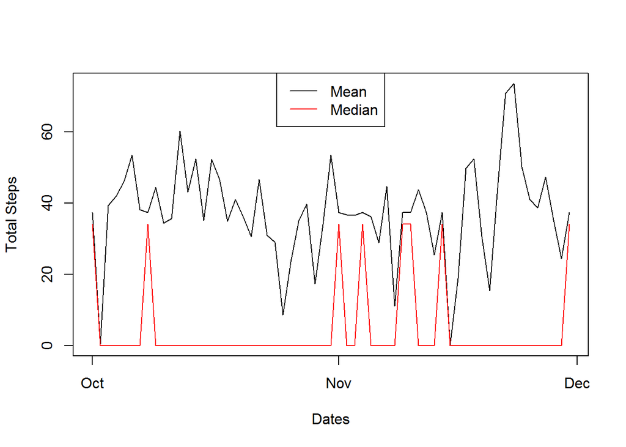

```r
  plot(sumnewstepsbydate$rawdate,sumnewstepsbydate$meansteps,type="l",col="black",ylab="Total Steps",xlab="Dates")
  lines(sumnewstepsbydate$rawdate,sumnewstepsbydate$mediansteps,type="l",col="red")
legend("top",legend=c("Mean","Median"),col=c("black","red"),lty=c(1,1))
```

## Are there differences in activity patterns between weekdays and weekends?

Behaviour according to the day of the week where the measure has been taken is likely change. In particular, it might be relevant to distinguish between weekday and weekend.

Calculate the total number of steps per interval and type of day based on the complete and modified dataset

```r
summarybyintervalandtypeofday<-summarise(group_by(finaldata,typeofday,interval),totalsteps=sum(modifiedsteps),meansteps=mean(modifiedsteps))
```

Finally plot the results

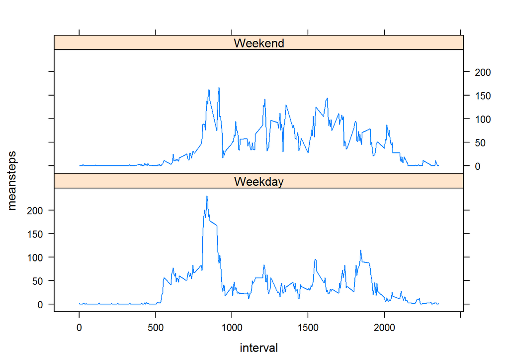

```r
xyplot(meansteps~interval | typeofday, data=summarybyintervalandtypeofday, layout=c(1,2),type="l")
```